# project_3_pipeline_analysis

Josiah Thulin

3/18/2021

```r
source("../Code/my_rf_cv.R")
library(ggplot2)
library(tidyverse)
# read in data from relative file path
my_gapminder <- read_csv(file = "../Data/my_gapminder.csv")
my_penguins <- read_csv(file = "../Data/my_penguins.csv")
```

## `my_rf_cv`: Random-forest algorithm statistical prediction

The function `my_rf_cv()` runs a random-forest statistical prediction algorithm on `my_penguins` data and performs k-fold cross validation on those prediction models. The following is a demonstration of the function.

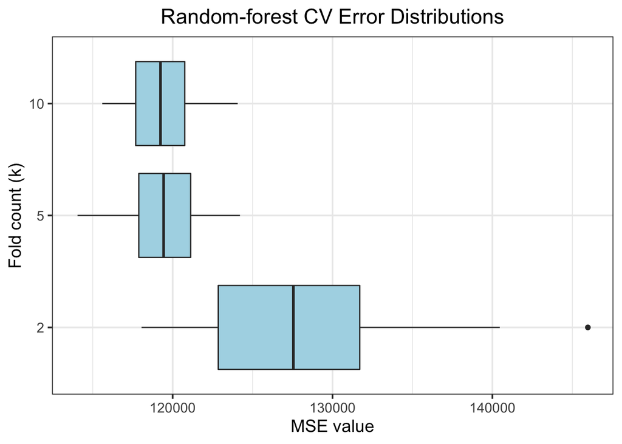

```r
rf_results <- NULL

# generate 30 MSE values for 2-, 5-, and 10-fold cross validation
for (i in c(2, 5, 10)) {
  for (j in 1:30) {
    rf_results <- append(rf_results, my_rf_cv(i))
  }
}

# format results into data frame for saving
rf_results_save <- matrix(rf_results,
                          nrow = 30,
                          ncol = 3,
                          dimnames = list(NULL,
                                          c("k = 2", "k = 5", "k = 10"))) %>%
  as.data.frame()

# save results
write.csv(rf_results_save, file = "../Output/Results/rf_results_save.csv")

# format results into data frame for generating plot
rf_results_df <- data.frame("k" = as.factor(rep(c(2, 5, 10), each = 30)),
                            "mse" = rf_results)

# generate plot with boxplots of my_rf_cv result distributions by k-value
rf_plot <- ggplot(rf_results_df, aes(x = mse, y = k)) +
  geom_boxplot(fill = "lightblue") +
  theme_bw(base_size = 14) +
  labs(x = "MSE value",
       y = "Fold count (k)",
       title = "Random-forest CV Error Distributions") +
  theme(plot.title = element_text(hjust = 0.5))

# save plot to local directory
ggsave("mse_boxplot.png", path = "../Output/Figures/")
# generate table with mean and std. dev of MSE values for each fold
rf_table <- rf_results_df %>%
  group_by(k) %>%
  summarize(mean(mse), sd(mse)) %>%
  as.data.frame()

colnames(rf_table) <- c("k", "mean", "sd")
rownames(rf_table) <- c("k = 2", "k = 5", "k = 10")

rf_table <- rf_table %>% select(mean, sd)

# save summary statistics table
saveRDS(rf_table, file = "../Output/Results/mse_summary_stats.rds")



# display plot and summary table
rf_plot
```

```r
knitr::kable(rf_table)
```

|  | mean | sd |
| --- | --- | --- |
| k = 2 | 128067.1 | 6517.756 |
| k = 5 | 119444.7 | 2604.077 |
| k = 10 | 119298.6 | 2196.637 |

From the boxplots, it is evident that higher values of k (greater numbers of folds in the cross-validation) results in lower mean squared-error values for the random-forest algorithm cross validation. Additionally, the spread of the distributions of MSE values decreases as k increases. The values in the table demonstrate this because the highest mean and standard deviation of MSE values is for k = 2 folds, with k = 5 folds having the next-lowest mean and standard deviation, and k = 10 folds has the lowest mean and standard deviation of MSE values. This could be because as the number of folds in the cross-validation increases, the less training-set bias there is in the estimate of the random-forest model error. The individual folds decrease in size, and the relative sizes of the in-fold and out-fold groups of data changes drastically. More of the data is tested against less of the data more times as the number of folds increases, decreasing the noise and bias in the error estimates.